# Transparent Conductors Predictions

> **John El Berch**

# Model Fitting

#### Test all the models

This notebook uses the `DataFit.py` script, which contains a couple of auxiliary functions and an object class called `DataFit`, made to help streamline the whole process, while allowing to check the score using different categorical variables.

### Important Notes

- I will use the RMSLE as the score to tune the models' hyper parameters (since it is used in the Kaggle competition for the score as well). One note is that, in the Kaggle competition, they compute the RMSLE considering both outputs (the bandgap and the formation energy). Technically speaking, I am approaching this problem as tuning the hyperparameters considering both outputs separately, and then choosing the best model for each type of output.
- The grids I defined contain a small number of parameters in order to save some computational time (considering I want to fit a large number of models with varying inputs)
- I will create csv files that will contain the predicted values of Bandgap and Formation energy. These will be computed using the best identified models for each case, and the `test.csv` dataset. These predictions will be then submitted to Kaggle to check the performance
- I won't taste the `binary_number_of_atoms` feature explored in the EDA, since it didn't showed any benefits

### Preprocessing operations

I will add new features following the comments made in the corrections of the project. These have been defined below. Moreover, as a general preprocessing operation, the continous inputs will be standarized, and dummy variables extracted from the categorical variables of interest. PCA will be considered for one case. If PCA or polynomial features are included, the continous inputs will be standarized one final time before fitting the models.

## Preliminars

### Import modules

```python
import matplotlib.pyplot as plt
import pandas as pd
import numpy as np
import seaborn as sns

from DataFit import *
```

### `train.csv`

```python
df_train = pd.read_csv('../train.csv')
df_train.head()
```

|  | id | spacegroup | number_of_total_atoms | percent_atom_al | percent_atom_ga | percent_atom_in | lattice_vector_1_ang | lattice_vector_2_ang | lattice_vector_3_ang | lattice_angle_alpha_degree | lattice_angle_beta_degree | lattice_angle_gamma_degree | formation_energy_ev_natom | bandgap_energy_ev |
| --- | --- | --- | --- | --- | --- | --- | --- | --- | --- | --- | --- | --- | --- | --- |
| 0 | 1 | 33 | 80.0 | 0.6250 | 0.3750 | 0.000 | 9.9523 | 8.5513 | 9.1775 | 90.0026 | 90.0023 | 90.0017 | 0.0680 | 3.4387 |
| 1 | 2 | 194 | 80.0 | 0.6250 | 0.3750 | 0.000 | 6.1840 | 6.1838 | 23.6287 | 90.0186 | 89.9980 | 120.0025 | 0.2490 | 2.9210 |
| 2 | 3 | 227 | 40.0 | 0.8125 | 0.1875 | 0.000 | 9.7510 | 5.6595 | 13.9630 | 90.9688 | 91.1228 | 30.5185 | 0.1821 | 2.7438 |
| 3 | 4 | 167 | 30.0 | 0.7500 | 0.0000 | 0.250 | 5.0036 | 5.0034 | 13.5318 | 89.9888 | 90.0119 | 120.0017 | 0.2172 | 3.3492 |
| 4 | 5 | 194 | 80.0 | 0.0000 | 0.6250 | 0.375 | 6.6614 | 6.6612 | 24.5813 | 89.9960 | 90.0006 | 119.9893 | 0.0505 | 1.3793 |

```python
df_train['spacegroup'] = df_train['spacegroup'].astype('category')
df_train['number_of_total_atoms_cat'] = df_train['number_of_total_atoms'].astype('category')
df_train['binary_number_of_total_atoms'] = np.where(df_train.number_of_total_atoms.to_numpy() == 80, '80', 'other')
```

### `test.csv`

```python
df_test = pd.read_csv('../test.csv')
df_test.head()
```

|  | id | spacegroup | number_of_total_atoms | percent_atom_al | percent_atom_ga | percent_atom_in | lattice_vector_1_ang | lattice_vector_2_ang | lattice_vector_3_ang | lattice_angle_alpha_degree | lattice_angle_beta_degree | lattice_angle_gamma_degree |
| --- | --- | --- | --- | --- | --- | --- | --- | --- | --- | --- | --- | --- |
| 0 | 1 | 33 | 80.0 | 0.1875 | 0.4688 | 0.3438 | 10.5381 | 9.0141 | 9.6361 | 89.9997 | 90.0003 | 90.0006 |
| 1 | 2 | 33 | 80.0 | 0.7500 | 0.2500 | 0.0000 | 9.8938 | 8.5014 | 9.1298 | 90.0038 | 90.0023 | 90.0015 |
| 2 | 3 | 167 | 30.0 | 0.6667 | 0.1667 | 0.1667 | 4.9811 | 4.9808 | 13.4799 | 89.9900 | 90.0109 | 120.0014 |
| 3 | 4 | 12 | 80.0 | 0.5625 | 0.4375 | 0.0000 | 24.3370 | 6.0091 | 5.7620 | 89.9995 | 103.8581 | 90.0002 |
| 4 | 5 | 12 | 80.0 | 0.1875 | 0.5000 | 0.3125 | 24.6443 | 6.2906 | 6.1589 | 90.0000 | 104.5929 | 90.0001 |

```python
df_test['spacegroup'] = df_test['spacegroup'].astype('category')
df_test['number_of_total_atoms_cat'] = df_test['number_of_total_atoms'].astype('category')
df_test['binary_number_of_total_atoms'] = np.where(df_test.number_of_total_atoms.to_numpy() == 80, '80', 'other')
```

## Define the new preprocessing features

New Variable 1: Deviations from ideal spacegroup data

```python
Spacegroup_df = pd.DataFrame({'alpha_theory' : [90, 90, 90, 90, 90, 90],
                             'gamma_theory' : [90, 90, 90, 120, 90, 120] ,
                            'spacegroup' : [206, 33, 227, 167, 12, 194]})
```

```python
prepro_df_train = pd.merge(left=Spacegroup_df,right=df_train.copy(), how='inner', on='spacegroup')
prepro_df_test = pd.merge(left=Spacegroup_df,right=df_test.copy(), how='inner', on='spacegroup')
```

```python
prepro_df_train['alpha_comparisson'] = prepro_df_train['lattice_angle_alpha_degree'] - prepro_df_train['alpha_theory']
prepro_df_train['gamma_comparisson'] = prepro_df_train['lattice_angle_gamma_degree'] - prepro_df_train['gamma_theory']
prepro_df_test['alpha_comparisson'] = prepro_df_test['lattice_angle_alpha_degree'] - prepro_df_test['alpha_theory']
prepro_df_test['gamma_comparisson'] = prepro_df_test['lattice_angle_gamma_degree'] - prepro_df_test['gamma_theory']
```

Create sigmoid feature

```python
def sigmoid(x):
    return np.exp(x) / (np.exp(x)+1) - 0.5
```

```python
prepro_df_train['alpha_sigmoid'] = sigmoid(prepro_df_train['alpha_comparisson'])
prepro_df_train['gamma_sigmoid'] = sigmoid(prepro_df_train['gamma_comparisson'])
prepro_df_test['alpha_sigmoid'] = sigmoid(prepro_df_test['alpha_comparisson'])
prepro_df_test['gamma_sigmoid'] = sigmoid(prepro_df_test['gamma_comparisson'])
```

Variable 2: Proportions between lattice constants

```python
prepro_df_train['a_to_b'] = prepro_df_train.lattice_vector_1_ang.to_numpy() / prepro_df_train.lattice_vector_2_ang.to_numpy()
prepro_df_test['a_to_b'] = prepro_df_test.lattice_vector_1_ang.to_numpy() / prepro_df_test.lattice_vector_2_ang.to_numpy()
```

```python
prepro_df_train['a_to_c'] = prepro_df_train.lattice_vector_1_ang.to_numpy() / prepro_df_train.lattice_vector_3_ang.to_numpy()
prepro_df_test['a_to_c'] = prepro_df_test.lattice_vector_1_ang.to_numpy() / prepro_df_test.lattice_vector_3_ang.to_numpy()
```

New Variable 3: Logit transformation of percentages

```python
'percent_atom_'

for element in ['al','ga','in']:
    for df in [prepro_df_test, prepro_df_train]:
        P = (df['percent_atom_'+element].to_numpy() - -0.01) / (1.02)
        OR = P / (1-P)
        df['logit_'+element] = np.log(OR)
```

New Variable 4: Log transformation of Bandgap energy

```python
prepro_df_train['log_bandgap'] = np.log(prepro_df_train.bandgap_energy_ev.to_numpy())
```

## Fit the first series of models

- Categorical to consider: `spacegroup`. `number_of_total_atoms` is considered a continous variable here.
- Continous variables: Will include the new-generated variables
- PCA? No

### Define the helping lists of inputs, outputs and categorical variables

```python
output_list = ['formation_energy_ev_natom', 'log_bandgap']

categorical_list = ['spacegroup']

exclude_list = ['alpha_theory', 'gamma_theory', 'id', 'percent_atom_al', 'percent_atom_in', 'percent_atom_ga',
                 'alpha_comparisson', 'gamma_comparisson', 'bandgap_energy_ev', 'number_of_total_atoms_cat', 'binary_number_of_total_atoms']

input_list = [var for var in prepro_df_train.columns.to_list() if var not in output_list+categorical_list+exclude_list]
```

##### Initialize the DataFit object

```python
DF_1_1 = DataFit(prepro_df_train, continous_inputs=input_list, categorical_inputs=categorical_list, output=output_list[0], use_PCA = False)
```

##### Execute the `FitAll()` Method

This method will fit all the models, store the results as attributes

```python
DF_1_1.FitAll()
```

[output not shown]

##### Execute the `PlotAll()` Method

This method will plot the main results (scores and standard deviations)

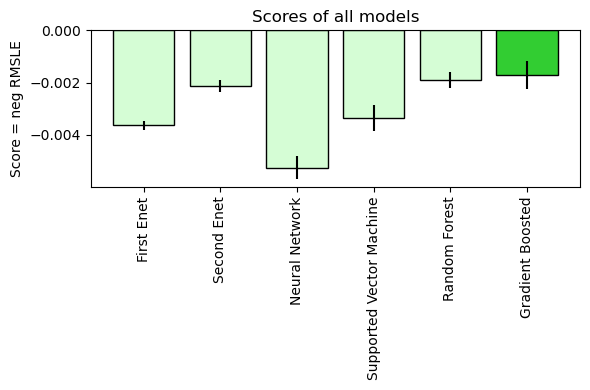

```python
DF_1_1.PlotAll()
```

##### Visualize how the hyper parameters affected the performance of the model

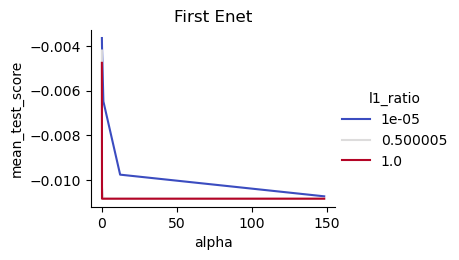

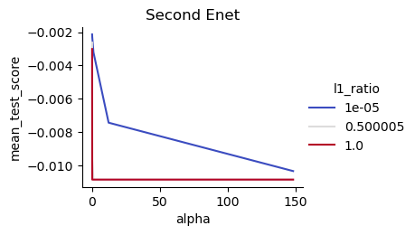

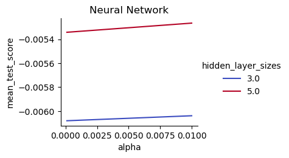

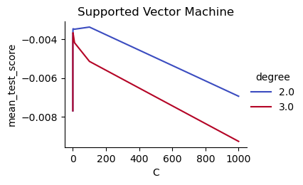

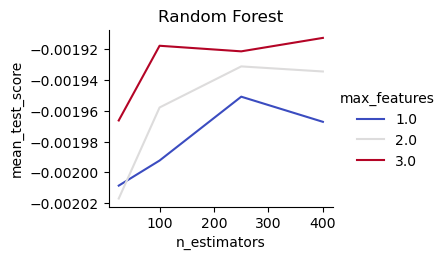

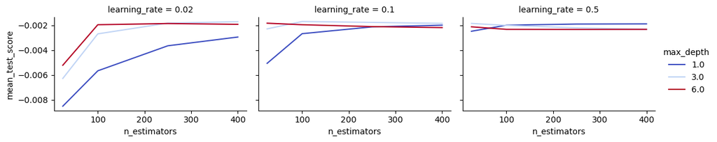

```python
DF_1_1.PlotEachModel()
```

##### Analyze the random forest

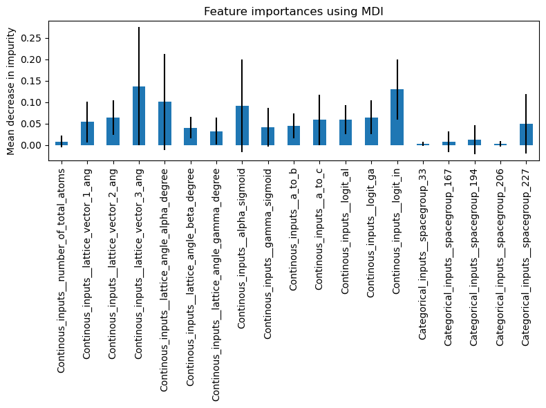

```python
DF_1_1.EvaluateRandomForest()
```

### Fit the log bandgap

##### Initialize the DataFit object

```python
DF_1_2 = DataFit(prepro_df_train, continous_inputs=input_list, categorical_inputs=categorical_list, output=output_list[1], use_PCA = False)
```

##### Execute the `FitAll()` Method

This method will fit all the models, store the results as attributes

```python
DF_1_2.FitAll()
```

[output not shown]

##### Execute the `PlotAll()` Method

This method will plot the main results (scores and standard deviations)

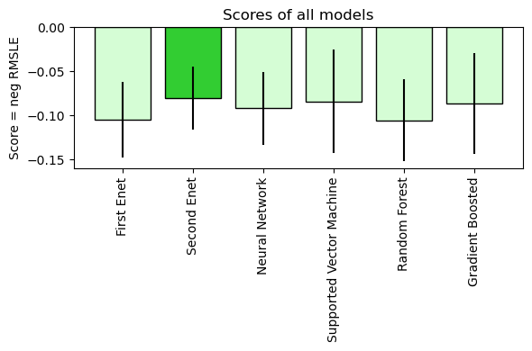

```python
DF_1_2.PlotAll()
```

##### Visualize how the hyper parameters affected the performance of the model

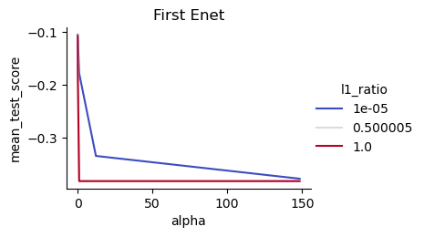

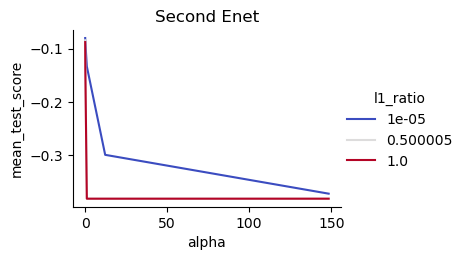

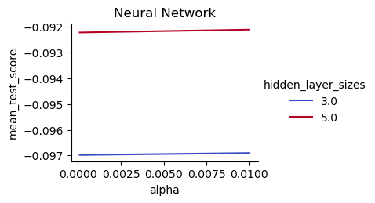

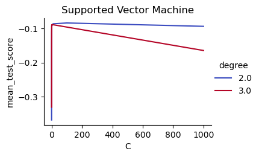

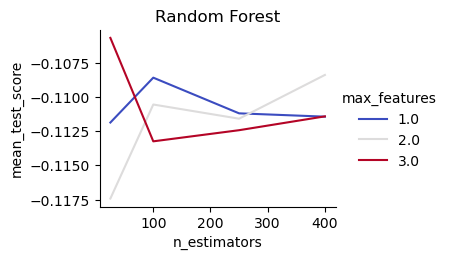

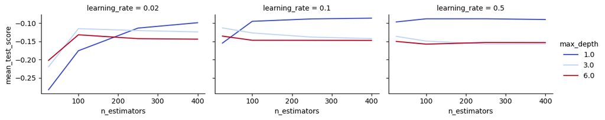

```python
DF_1_2.PlotEachModel()
```

##### Analyze the random forest

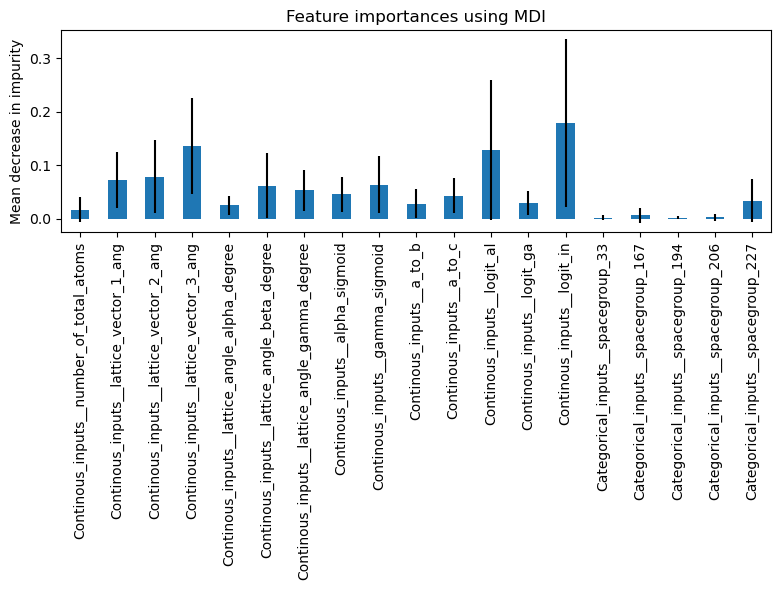

```python
DF_1_2.EvaluateRandomForest()
```

### Save the predictions into a csv file

```python
pd.DataFrame({'formation_energy_ev_natom' : DF_1_1.GBM_results.predict(prepro_df_test),
                          'bandgap_energy_ev' : 10**DF_1_2.SecondEnet_results.predict(prepro_df_test)},
                         index=prepro_df_test.id.copy()).to_csv('First_models.csv')
```

## Fit the second series of models

### Define the helping lists of inputs, outputs and categorical variables

```python
output_list = ['formation_energy_ev_natom', 'log_bandgap']

categorical_list = ['spacegroup']

exclude_list = ['alpha_theory', 'gamma_theory', 'id', 'percent_atom_al', 'percent_atom_in', 'percent_atom_ga', 'number_of_total_atoms',
                 'alpha_comparisson', 'gamma_comparisson', 'bandgap_energy_ev', 'number_of_total_atoms_cat', 'binary_number_of_total_atoms']

input_list = [var for var in prepro_df_train.columns.to_list() if var not in output_list+categorical_list+exclude_list]
```

##### Initialize the DataFit object

```python
DF_2_1 = DataFit(prepro_df_train, continous_inputs=input_list, categorical_inputs=categorical_list, output=output_list[0], use_PCA = True)
```

##### Execute the `FitAll()` Method

This method will fit all the models, store the results as attributes

```python
DF_2_1.FitAll()
```

[output not shown]

##### Execute the `PlotAll()` Method

This method will plot the main results (scores and standard deviations)

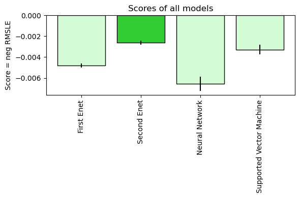

```python
DF_2_1.PlotAll()
```

##### Visualize how the hyper parameters affected the performance of the model

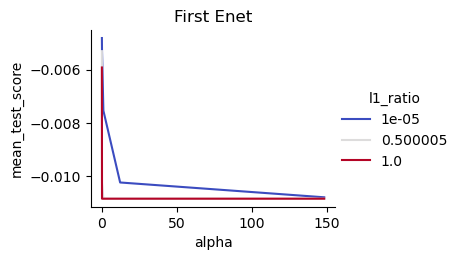

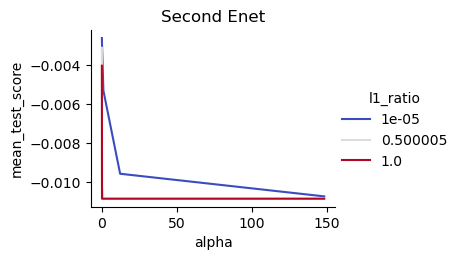

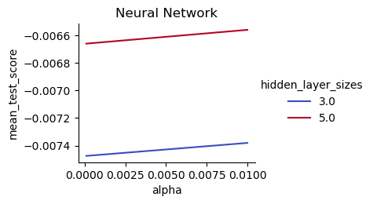

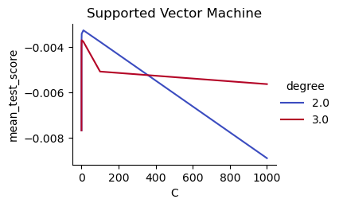

```python
DF_2_1.PlotEachModel()
```

### Fit the log bandgap

##### Initialize the DataFit object

```python
DF_2_2 = DataFit(prepro_df_train, continous_inputs=input_list, categorical_inputs=categorical_list, output=output_list[1], use_PCA = True)
```

##### Execute the `FitAll()` Method

This method will fit all the models, store the results as attributes

```python
DF_2_2.FitAll()
```

[output not shown]

[output cut: 18 more lines]

##### Execute the `PlotAll()` Method

This method will plot the main results (scores and standard deviations)

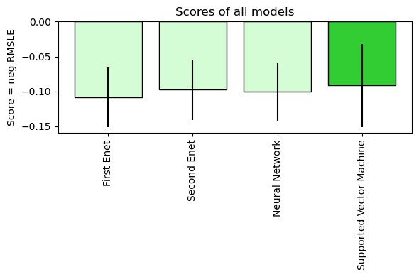

```python
DF_2_2.PlotAll()
```

##### Visualize how the hyper parameters affected the performance of the model

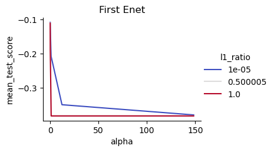

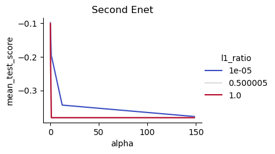

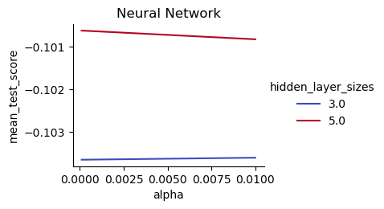

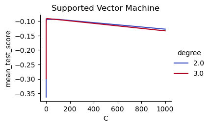

```python
DF_2_2.PlotEachModel()
```

### Save the predictions into a csv file

```python
pd.DataFrame({'formation_energy_ev_natom' : DF_2_1.SecondEnet_results.predict(prepro_df_test),
                          'bandgap_energy_ev' : 10**DF_2_2.SecondEnet_results.predict(prepro_df_test)},
                         index=prepro_df_test.id.copy()).to_csv('Second_models.csv')
```

## Fit the third series of models

- Categorical to consider: `spacegroup`. `number_of_total_atoms` is not considered at all.
- Continous variables: Will include the new-generated variables
- PCA? No

### Define the helping lists of inputs, outputs and categorical variables

```python
output_list = ['formation_energy_ev_natom', 'log_bandgap']

categorical_list = ['spacegroup']

exclude_list = ['alpha_theory', 'gamma_theory', 'id', 'percent_atom_al', 'percent_atom_in', 'percent_atom_ga', 'number_of_total_atoms',
                 'alpha_comparisson', 'gamma_comparisson', 'bandgap_energy_ev', 'number_of_total_atoms_cat', 'binary_number_of_total_atoms']

input_list = [var for var in prepro_df_train.columns.to_list() if var not in output_list+categorical_list+exclude_list]
```

##### Initialize the DataFit object

```python
DF_3_1 = DataFit(prepro_df_train, continous_inputs=input_list, categorical_inputs=categorical_list, output=output_list[0], use_PCA = False)
```

##### Execute the `FitAll()` Method

This method will fit all the models, store the results as attributes

```python
DF_3_1.FitAll()
```

[output not shown]